# 1. Giới thiệu và cài đặt Anaconda

Anaconda là một nền tảng phân phối miễn phí của ngôn ngữ lập trình Python và R cho tính toán khoa học (khoa học dữ liệu, machine learning, xử lý dữ liệu lớn, phân tích dự đoán, v.v.), nhằm mục đích đơn giản hóa việc quản lý và triển khai gói. Nó có trên cả Windows, MacOS và Linux.

Anaconda chứa tất cả các gói (công cụ) phổ biến nhất mà một nhà khoa học dữ liệu cần. Các package trong Anaconda được quản lý bởi trình quản lý riêng của nền tảng này là conda. Ta thường dùng conda để tạo môi trường cô lập các dự án của mình, nhằm sử dụng các phiên bản Python khác nhau hoặc các phiên bản package khác nhau, cũng như dùng nó để cài đặt, gỡ cài đặt và cập nhật các package riêng trong từng dự án. Ta có thể thấy về cơ bản, conda hoạt động gần giống như pip - trình quản lý gói của Python.

Anaconda không chỉ gồm có Python, mà còn có hơn 600 package mở rộng đi kèm, đó là các package cơ bản cho các tác vụ xử lý khoa học dữ liệu như NumPy, Pandas,.... Bạn không cần phải nhập các lệnh trên terminal để tải về nữa, chỉ cần tải Anaconda là có thể sử dụng ngay các package đó, giúp tiết kiệm khá nhiều thời gian cho chúng ta.

## 1.1. Cài đặt Anaconda

Để cài đặt Anaconda, truy cập vào đường link sau ([Individual Edition](https://www.anaconda.com/products/individual)) để tải và cài đặt phiên bản cá nhân miễn phí.

[figure not shown]

Chọn phiên bản 64bit hoặc 32bit tùy thuộc vào hệ điều hành đang sử dụng.

[figure not shown]

## 1.2. Giới thiệu về Jupiter Notebook

[Jupyter](https://jupyter.org/) là nền tảng, dịch vụ **tính toán tương tác** (interactive computing) hỗ trợ rất nhiều ngôn ngữ (Julia, Python, R, ...). [Jupyter Notebook](https://jupyter-notebook.readthedocs.io/en/stable/), hay mới hơn là [JupyterLab](https://jupyterlab.readthedocs.io/en/latest/), là các ứng dụng Web giúp làm việc với các file notebook. Anaconda tự động cài Jupyter Notebook và JupyterLab.

[Jupyter notebook](https://jupyterlab.readthedocs.io/en/latest/user/notebook.html) (file `.ipynb`) là tài liệu kết hợp nhiều định dạng: văn bản thô, văn bản có định dạng, biểu đồ, công thức, ... và đặc biệt là **mã thực thi** (code) có thể được viết bằng nhiều ngôn ngữ khác nhau. Jupyter notebook là tài liệu động và có tính tương tác nên rất phù hợp với các văn bản, trình bày tính toán khoa học. Jupyter notebook cũng có thể được kết xuất ra nhiều định dạng phổ biến khác nhau (PDF, HTML, LaTex, ...).

Jupyter notebook hỗ trợ định dạng văn bản [Markdown](https://www.markdownguide.org/basic-syntax/) và [HTML](https://www.w3schools.com/html/); hỗ trợ định dạng công thức Toán [LaTeX](https://en.wikibooks.org/wiki/LaTeX/Mathematics). Tham khảo nhanh tại [Learn How to Write Markdown & LaTeX in The Jupyter Notebook](https://towardsdatascience.com/write-markdown-latex-in-the-jupyter-notebook-10985edb91fd).

Sau khi đã cài đặt Anaconda, ta có thể mở Jupiter notebook trên Anaconda.

[figure not shown]

Sau đó thì trên terminal sẽ hiển thị như sau:

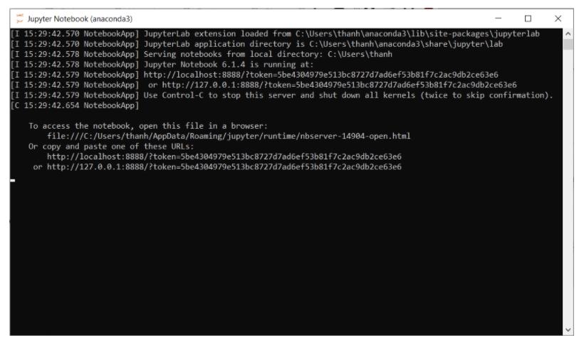

Và sau đó thì trình duyệt sẽ bật ra một trang web như sau:

[figure not shown]

## Tạo và chạy một notebook

Để tạo một notebook, ta nhấp chuột vào nút New nằm ở bên góc phải và chọn Python 3:

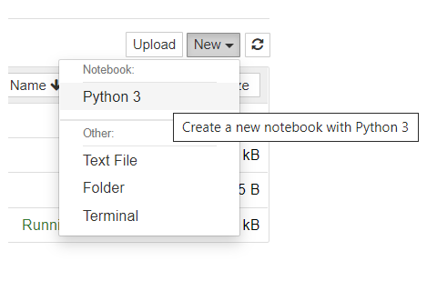

Mọi notebook mới tạo đều được đặt tên là Untitled, nếu muốn sửa bạn chỉ cần nhấp chuột vào tên, môt hộp thoại đổi tên sẽ bật ra như sau:

[figure not shown]

## Giao diện của Notebook

Trong 1 notebook sẽ có 4 phần chính (đánh số theo thứ tự từ 1, 2, 3, 4) như sau:

[figure not shown]

1: Tên của file notebook, tương ứng với tên file .ipynb.

2: Thanh Menu hiển thị nhiều chức năng khác nhau để điều khiển notebook.

3: Thanh công cụ (toolbar) chứa các công cụ được sử dụng nhiều (run, di chuyển code cell lên xuống, restart kernel...).

4: Code cell (nơi sẽ nhập các dòng lệnh)

### Cell code

Một notebook bao gồm một chuỗi các cell. Một cell giống như một text editor mini, có thể thực thi code bằng tổ hợp phím Shift + Enter hoặc nhấn nút Run trên toolbar.

**Code**: Là kiểu hay dùng nhất, nhập và thực thi code trên loại cell này. Để thực thi code, có thể nhấn nút Run cell hoặc nhấn Ctrl + Enter.

```python
print(" Hello python")
```

```
 Hello python
```

```python
x=8
y=10
x+y
```

```
18
```

Sau khi nhập dòng code trên và thực thi thì ta sẽ thấy kết quả của dòng lệnh được thực hiện ngay bên dưới của cell đó.

**Markdown**: để viết những đoạn văn bản hoặc dùng để giải thích đoạn code đã viết.

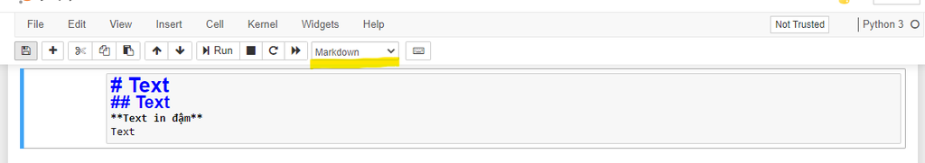